# Case Study One (1)

## How many breweries are present in each State?

```r
#Total Breweries by state
# Read in the breweries data
breweries <- read.csv("breweries.csv", header  = TRUE)
# compile the number by state using the aggregate function in R
breweries.by.State <- aggregate( rep(1,dim(breweries)[1]), by=list(breweries$State), sum)
# Update the column names to something more meaningful
colnames(breweries.by.State) <- c("State","Number")
# Sort by state from largest to smallest number of breweries
sortedBreweriesByState <- breweries.by.State[order(breweries.by.State$Number, decreasing = TRUE),]
# Display the Breweries by States in descending order top 6
head(sortedBreweriesByState,6)
```

```
##    State Number
## 6     CO     47
## 5     CA     39
## 23    MI     32
## 38    OR     29
## 44    TX     28
## 39    PA     25
```

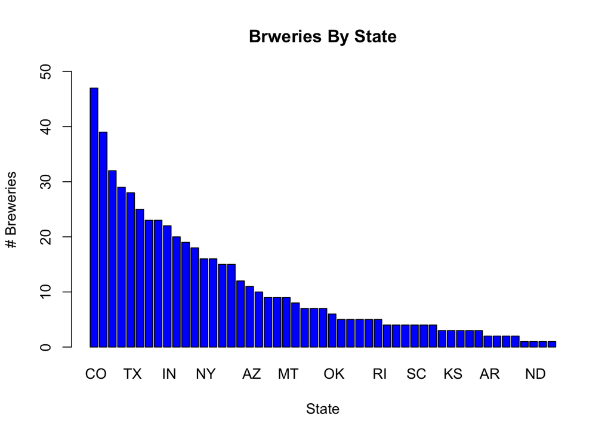

```r
# DIsplay as BarChart for easier viewing of a large data set
barplot(sortedBreweriesByState[,2], beside = TRUE, names.arg = sortedBreweriesByState$State,ylab="# Breweries", main = "Brweries By State", xlab = "State",ylim=c(0,50),col="Blue")
```

## Merge beer data with the breweries data. Print the first 6

## observations and the last 6 observation to check the merged

## data

```r
# Merge Data and then head(6), then tail(6)
Beer <- read.csv(file="Beers.csv", header=TRUE, sep=",")
Breweries <-read.csv(file="Breweries.csv", header=TRUE, sep=",")

BeerBreweries <- merge(Beer, Breweries, by.x="Brewery_id", by.y="Brew_ID", all=TRUE)
colnames(BeerBreweries) <- c("Brewery_ID","Beer","Beer_ID","ABV","IBU","Style","Ounces","Brewery","City","State")
# First 6 Merged Beer and Breweries
head(BeerBreweries,6)
```

```
##   Brewery_ID          Beer Beer_ID   ABV IBU
## 1          1  Get Together    2692 0.045  50
## 2          1 Maggie's Leap    2691 0.049  26
## 3          1    Wall's End    2690 0.048  19
## 4          1       Pumpion    2689 0.060  38
## 5          1    Stronghold    2688 0.060  25
## 6          1   Parapet ESB    2687 0.056  47
##                                 Style Ounces            Brewery
## 1                        American IPA     16 NorthGate Brewing
## 2                  Milk / Sweet Stout     16 NorthGate Brewing
## 3                   English Brown Ale     16 NorthGate Brewing
## 4                         Pumpkin Ale     16 NorthGate Brewing
## 5                     American Porter     16 NorthGate Brewing
## 6 Extra Special / Strong Bitter (ESB)     16 NorthGate Brewing
##          City State
## 1 Minneapolis    MN
## 2 Minneapolis    MN
## 3 Minneapolis    MN
## 4 Minneapolis    MN
## 5 Minneapolis    MN
## 6 Minneapolis    MN
```

```r
# Last 6 Merged Beer and Breweries
tail(BeerBreweries,6)
```

```
##      Brewery_ID                      Beer Beer_ID   ABV IBU
## 2405        556             Pilsner Ukiah      98 0.055  NA
## 2406        557  Heinnieweisse Weissebier      52 0.049  NA
## 2407        557           Snapperhead IPA      51 0.068  NA
## 2408        557         Moo Thunder Stout      50 0.049  NA
## 2409        557         Porkslap Pale Ale      49 0.043  NA
## 2410        558 Urban Wilderness Pale Ale      30 0.049  NA
##                        Style Ounces                       Brewery
## 2405         German Pilsener     12         Ukiah Brewing Company
## 2406              Hefeweizen     12       Butternuts Beer and Ale
## 2407            American IPA     12       Butternuts Beer and Ale
## 2408      Milk / Sweet Stout     12       Butternuts Beer and Ale
## 2409 American Pale Ale (APA)     12       Butternuts Beer and Ale
## 2410        English Pale Ale     12 Sleeping Lady Brewing Company
##               City State
## 2405         Ukiah    CA
## 2406 Garrattsville    NY
## 2407 Garrattsville    NY
## 2408 Garrattsville    NY
## 2409 Garrattsville    NY
## 2410     Anchorage    AK
```

## Report the number of NA’s in each column

```
## Number of NA's in Brewery ID Column: 0
```

[output not shown]

```
## Number of NA's in Beer ID Column: 0
```

```
## Number of NA's in ABV Column: 62
```

```
## Number of NA's in IBU Column: 1005
```

```
## Number of NA's in Style Column: 0
```

```
## Number of NA's in Ounces Column: 0
```

```
## Number of NA's in Brewer name Column: 0
```

```
## Number of NA's in City Column: 0
```

```
## Number of NA's in State Column: 0
```

## Compute the median alcohol content and international

## bitterness unit for each state. Plot a bar chart to compare.

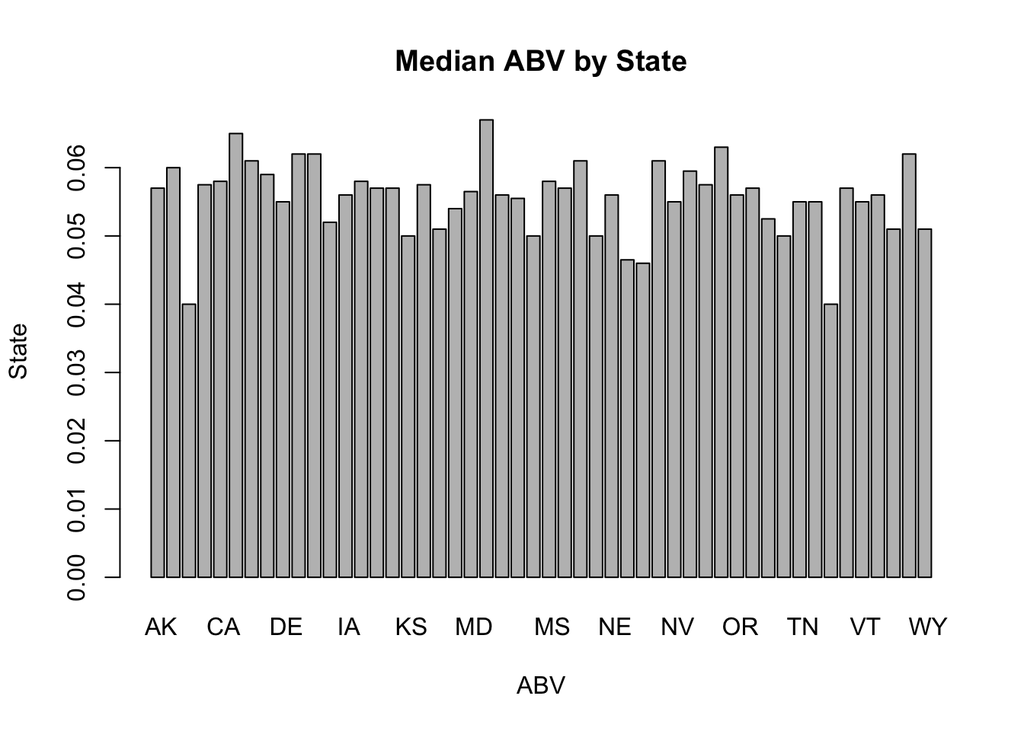

```r
BeerBreweriesDF <-na.omit(BeerBreweries)
ByState <- aggregate(BeerBreweriesDF[,4:5], list(BeerBreweriesDF$State), median)
barplot(ByState[,2], beside = TRUE, names.arg = ByState$Group.1,xlab="ABV", main = "Median ABV by State", ylab = "State")
```

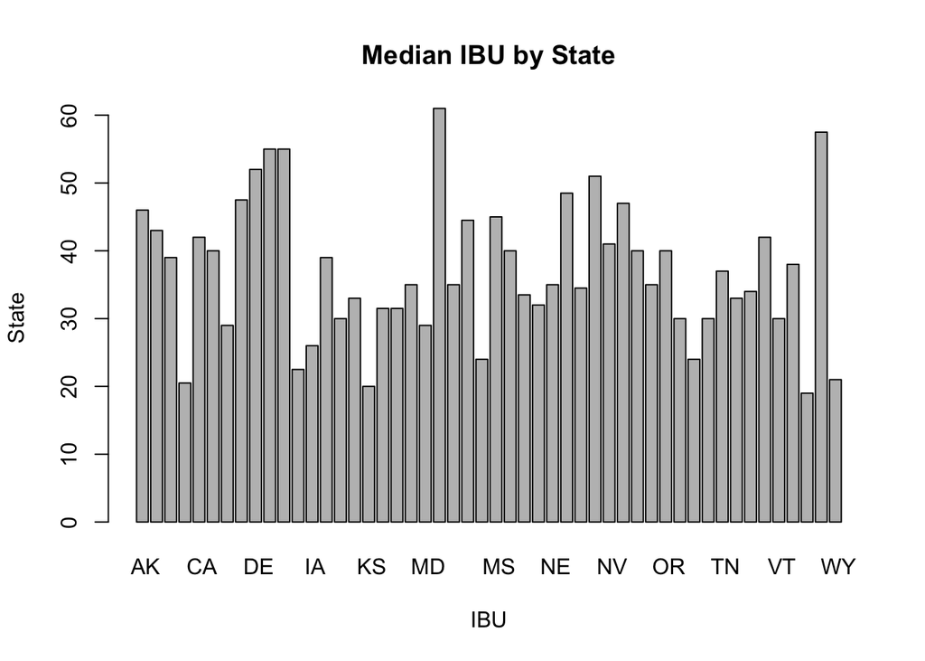

```r
barplot(ByState[,3], beside = TRUE, names.arg = ByState$Group.1,xlab="IBU", main = "Median IBU by State", ylab = "State")
```

## Which State has the maximum alcoholic (ABV) beer?

## Which state has the most IBU Beer?

```r
# State with the max ABV
BeerBreweries[which(BeerBreweries$ABV == max(BeerBreweries$ABV, na.rm=TRUE)),10]
```

```
## [1]  CO
## 51 Levels:  AK  AL  AR  AZ  CA  CO  CT  DC  DE  FL  GA  HI  IA  ID ...  WY
```

```r
# State with the max IBU
BeerBreweries[which(BeerBreweries$IBU == max(BeerBreweries$IBU, na.rm=TRUE)),10]
```

```
## [1]  OR
## 51 Levels:  AK  AL  AR  AZ  CA  CO  CT  DC  DE  FL  GA  HI  IA  ID ...  WY
```

## Summary Statistics for the ABV variable.

```r
# Summary ABV
summary(BeerBreweries$ABV)
```

```
##    Min. 1st Qu.  Median    Mean 3rd Qu.    Max.    NA's
## 0.00100 0.05000 0.05600 0.05977 0.06700 0.12800      62
```

## Is there an apparent relationship between the

## bitterness of the beer and it’s alcoholic content?

## Draw a scatter plot

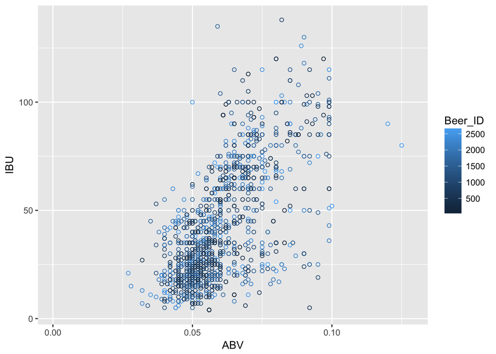

```r
# Relationship
# ScatterPlot
library(ggplot2)
# Read in the beers data
Beer <- read.csv(file="Beers.csv", header=TRUE, sep=",")
# Read in the breweries data
Breweries <-read.csv(file="Breweries.csv", header=TRUE, sep=",")

##Merge the files and assign to variable
BeerBreweries <- merge(Beer, Breweries, by.x="Brewery_id", by.y="Brew_ID", all=TRUE)
# Build Scatter plot
attach(BeerBreweries)
ggplot(BeerBreweries, aes(x=ABV, y=IBU, color=Beer_ID)) + geom_point(shape=1)
```

## Hops were first introduced into the Beer making process in 1150-1160 AD to add as a preservative.

#### “[The hop plant] is warm and dry, and has moderate moisture, and is not very useful in benefiting man, because it makes melancholy grow in man and makes the soul of man sad, and weighs down his inner organs. But yet, as a result of its own bitterness it keeps some putrefactions from drinks, to which it may be added, so that they may last so much longer (1)(2).

“A short history of hops” — http://zythophile.wordpress.com/2009/11/20/a-short-history-of-hops/

## So, my starting assumption would be that the lower the alcohol would thus have the highest Hops Level, since Alcohol is a preservative as well. However, the Scatter Plot shows the opposite. That the higher the alcohol, the higher the Hops content. But after continuing the research on the use of hops in modern beer making i found that there an actual Hops/Malt ratio that to conteract the sweetness of the malt used in beer (Sweetness) that there is a particular ratio of Hops to be used. This is what is reflected in the scatter gram is this ratio of increased alcohol correlates to the increase in hops (IBU). For a full explanation see the following website:

Balancing your Beer with the Bitterness Ratio - “http://beersmith.com/blog/2009/09/26/balancing-your-beer-with-the-bitterness-ratio/”

## The final Scatter Plot below shows a clear separation between the two groups of beer types of dark vs light.

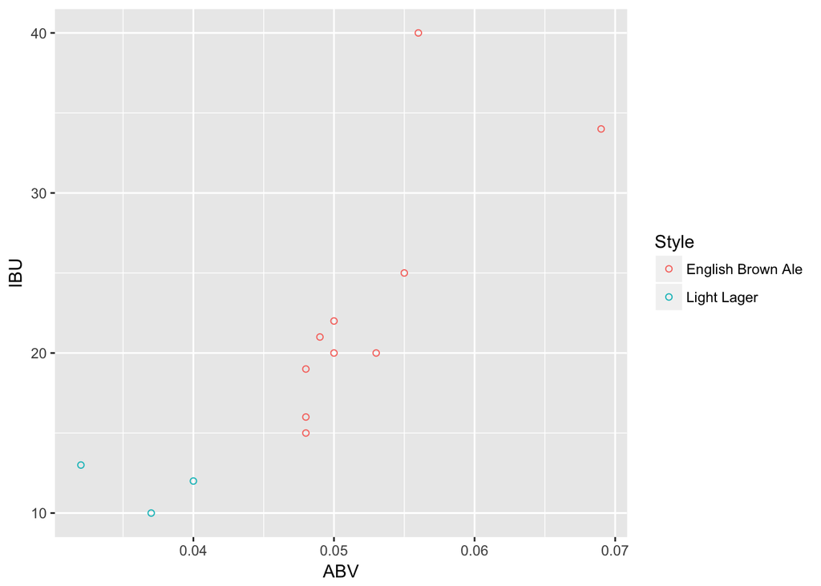

```r
# Relationship
# Dark Vs LIght ScatterPlot
library(ggplot2)
# Read in the beers data
Beer <- read.csv(file="Beers.csv", header=TRUE, sep=",")
# Read in the breweries data
Breweries <-read.csv(file="Breweries.csv", header=TRUE, sep=",")

##Merge the files and assign to variable
BeerBreweries <- merge(Beer, Breweries, by.x="Brewery_id", by.y="Brew_ID", all=TRUE)

#Compare Light Beers to Dark Ales
DarkAles <- BeerBreweries[BeerBreweries$Style == "English Brown Ale",]
LightLagers <- BeerBreweries[BeerBreweries$Style == "Light Lager",]
ComparedBeers <- merge(DarkAles,LightLagers,all=TRUE)

attach(ComparedBeers)
ggplot(ComparedBeers, aes(x=ABV, y=IBU, color=Style)) + geom_point(shape=1)
```

###### 1. A myth states that the original writing, by the Abbess Hildegarde of Bingen is from 1079 AD. She wasn’t born until 1098. She did write about hops first in her “Physica Sacra”, written between 1150–1160. American beer writer John P Arnold did try to dispell the myth as far back as 1911, but to no avail. http://en.wikipedia.org/wiki/Hildegard_of_Bingen http://zythophile.wordpress.com/false-ale-quotes/six-more-myths-about-hops/

###### 2. “A short history of hops” — http://zythophile.wordpress.com/2009/11/20/a-short-history-of-hops/